# RelativePermeability

2020-06-21

# Rrelperm

`Rrelperm` generates relative permeability values for two- and/or three-phase mixtures of water and hydrocarbons. It estimates the two-phase relative permeabilities for the water-oil and gas-liquid systems in a tabular format using the modified Brooks-Corey correlation (Brooks & Corey, 1964). It calculates the three-phase relative permeabilities using the modified Stone I, Stone II, and Baker’s linear models (Baker, 1988; Fayers & Matthews, 1984; Stone, 1970).

## Relative Permeability Parameters

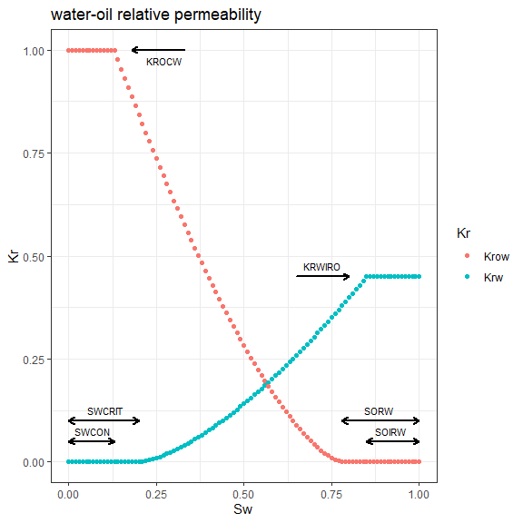

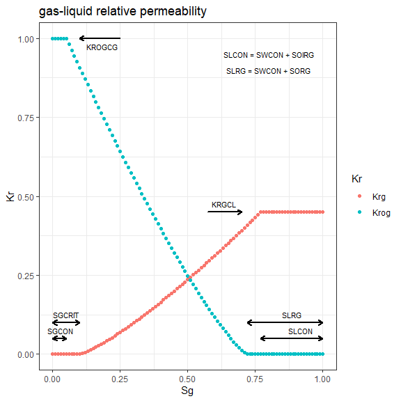

## `kr2p_ow() arguments`

- `SWCON`: connate water saturation, fraction.
- `SWCRIT`: critical water saturation, fraction.
- `SOIRW`: irreducible oil saturation, fraction.
- `SORW`: residual oil saturation, fraction.
- `KRWIRO`: water relative permeability at irreducible oil.
- `KROCW`: oil relative permeability at connate water.
- `NW`: exponent term for calculating krw.
- `NOW`: exponent term for calculating krow.
- `NP`: number of saturation points in the table, the maximum acceptable value is 501.

## `kr2p_gl() arguments`

- `SWCON`: connate water saturation, fraction.
- `SOIRG`: irreducible oil saturation, fraction.
- `SORG`: residual oil saturation, fraction.
- `SGCON`: connate gas saturation, fraction.
- `SGCRIT`: critical gas saturation, fraction.
- `KRGCL`: gas relative permeability at connate liquid.
- `KROGCG`: oil relative permeability at connate gas.
- `NG`: exponent term for calculating krg.
- `NOG`: exponent term for calculating krog.
- `NP`: number of saturation points in the table, the maximum acceptable value is 501.

## `kr3p_StoneI_So() arguments`

- `SWCON`: connate water saturation, fraction.
- `SWCRIT`: critical water saturation, fraction.
- `SOIRW`: irreducible oil saturation, fraction.
- `SORW`: residual oil saturation, fraction.
- `SOIRG`: irreducible oil saturation, fraction.
- `SORG`: residual oil saturation, fraction.
- `SGCON`: connate gas saturation, fraction.
- `SGCRIT`: critical gas saturation, fraction.
- `KRWIRO`: water relative permeability at irreducible oil.
- `KROCW`: oil relative permeability at connate water.
- `KRGCL`: gas relative permeability at connate liquid.
- `KROGCG`: oil relative permeability at connate gas.
- `NW`: exponent term for calculating krw.
- `NOW`: exponent term for calculating krow.
- `NG`: exponent term for calculating krg.
- `NOG`: exponent term for calculating krog.
- `NP`: number of saturation points in the two-phase relative permeability tables, the maximum acceptable value is 501. The number of data points in the three-phase relative permeability table is (0.5 * NP * (NP + 1)).

## `kr3p_StoneI_SwSg() arguments`

- `SWCON`: connate water saturation, fraction.
- `SWCRIT`: critical water saturation, fraction.
- `SOIRW`: irreducible oil saturation, fraction.
- `SORW`: residual oil saturation, fraction.
- `SOIRG`: irreducible oil saturation, fraction.
- `SORG`: residual oil saturation, fraction.
- `SGCON`: connate gas saturation, fraction.
- `SGCRIT`: critical gas saturation, fraction.
- `KRWIRO`: water relative permeability at irreducible oil.
- `KROCW`: oil relative permeability at connate water.
- `KRGCL`: gas relative permeability at connate liquid.
- `KROGCG`: oil relative permeability at connate gas.
- `NW`: exponent term for calculating krw.
- `NOW`: exponent term for calculating krow.
- `NG`: exponent term for calculating krg.
- `NOG`: exponent term for calculating krog.
- `NP`: number of saturation points in the two-phase relative permeability tables, the maximum acceptable value is 501. The number of data points in the three-phase relative permeability table is (0.5 * NP * (NP + 1)).

## `kr3p_StoneII_So() arguments`

- `SWCON`: connate water saturation, fraction.
- `SWCRIT`: critical water saturation, fraction.
- `SOIRW`: irreducible oil saturation, fraction.
- `SORW`: residual oil saturation, fraction.
- `SOIRG`: irreducible oil saturation, fraction.
- `SORG`: residual oil saturation, fraction.
- `SGCON`: connate gas saturation, fraction.
- `SGCRIT`: critical gas saturation, fraction.
- `KRWIRO`: water relative permeability at irreducible oil.
- `KROCW`: oil relative permeability at connate water.
- `KRGCL`: gas relative permeability at connate liquid.
- `KROGCG`: oil relative permeability at connate gas.
- `NW`: exponent term for calculating krw.
- `NOW`: exponent term for calculating krow.
- `NG`: exponent term for calculating krg.
- `NOG`: exponent term for calculating krog.
- `NP`: number of saturation points in the two-phase relative permeability tables, the maximum acceptable value is 501. The number of data points in the three-phase relative permeability table is (0.5 * NP * (NP + 1)).

## `kr3p_StoneII_SwSg() arguments`

- `SWCON`: connate water saturation, fraction.
- `SWCRIT`: critical water saturation, fraction.
- `SOIRW`: irreducible oil saturation, fraction.
- `SORW`: residual oil saturation, fraction.
- `SOIRG`: irreducible oil saturation, fraction.
- `SORG`: residual oil saturation, fraction.
- `SGCON`: connate gas saturation, fraction.
- `SGCRIT`: critical gas saturation, fraction.
- `KRWIRO`: water relative permeability at irreducible oil.
- `KROCW`: oil relative permeability at connate water.
- `KRGCL`: gas relative permeability at connate liquid.
- `KROGCG`: oil relative permeability at connate gas.
- `NW`: exponent term for calculating krw.
- `NOW`: exponent term for calculating krow.
- `NG`: exponent term for calculating krg.
- `NOG`: exponent term for calculating krog.
- `NP`: number of saturation points in the two-phase relative permeability tables, the maximum acceptable value is 501. The number of data points in the three-phase relative permeability table is (0.5 * NP * (NP + 1)).

## `kr3p_Baker() arguments`

- `SWCON`: connate water saturation, fraction.
- `SWCRIT`: critical water saturation, fraction.
- `SOIRW`: irreducible oil saturation, fraction.
- `SORW`: residual oil saturation, fraction.
- `SOIRG`: irreducible oil saturation, fraction.
- `SORG`: residual oil saturation, fraction.
- `SGCON`: connate gas saturation, fraction.
- `SGCRIT`: critical gas saturation, fraction.
- `KRWIRO`: water relative permeability at irreducible oil.
- `KROCW`: oil relative permeability at connate water.
- `KRGCL`: gas relative permeability at connate liquid.
- `KROGCG`: oil relative permeability at connate gas.
- `NW`: exponent term for calculating krw.
- `NOW`: exponent term for calculating krow.
- `NG`: exponent term for calculating krg.
- `NOG`: exponent term for calculating krog.
- `NP`: number of saturation points in the two-phase relative permeability tables, the maximum acceptable value is 501. The number of data points in the three-phase relative permeability table is (0.5 * NP * (NP + 1)).

## `Installation`

The `Rrelperm` can be installed from [CRAN](https://CRAN.R-project.org) with:

```r
install.packages("Rrelperm")
```

## `Two-phase Relative Permeability Examples`

#### Example 1:

```r
library(Rrelperm)
library(ggplot2)
library(magrittr)
library(tidyr)

rel_perm_ow <- kr2p_ow(SWCON = 0.13, SWCRIT = 0.13, SOIRW = 0.20, SORW = 0.2,
                       KRWIRO = 0.45, KROCW = 1, NW = 4.25, NOW = 2.5, NP = 101)

rel_perm_ow_df <- as.data.frame(rel_perm_ow)
colnames(rel_perm_ow_df) <- c("Sw", "So", "Krw", "Krow")

head(rel_perm_ow_df, 10)
```

```
#>      Sw   So Krw Krow
#> 1  0.00 1.00   0    1
#> 2  0.01 0.99   0    1
#> 3  0.02 0.98   0    1
#> 4  0.03 0.97   0    1
#> 5  0.04 0.96   0    1
#> 6  0.05 0.95   0    1
#> 7  0.06 0.94   0    1
#> 8  0.07 0.93   0    1
#> 9  0.08 0.92   0    1
#> 10 0.09 0.91   0    1
```

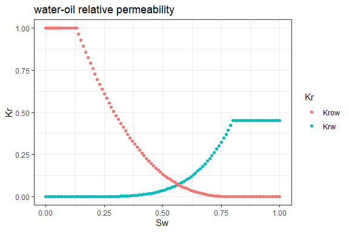

```r
p1 <- rel_perm_ow_df %>% tidyr::pivot_longer(cols = c(Krw, Krow), values_to = "value",
                                             names_to = "Kr") %>%
  ggplot(aes(x = Sw, y = value, col = Kr)) +
  geom_point() +
  labs(title = "water-oil relative permeability", x = "Sw", y = "Kr") +
  theme_bw()

p1
```

#### Example 2:

```r
library(Rrelperm)
library(ggplot2)
library(magrittr)

rel_perm_gl <- kr2p_gl(SWCON = 0.13, SOIRG = 0.12, SORG = 0.12, SGCON = 0.05,
                       SGCRIT = 0.05, KRGCL = 0.35, KROGCG = 1, NG = 4.25, NOG = 2.5,
                       NP = 101)

rel_perm_gl_df <- as.data.frame(rel_perm_gl)
colnames(rel_perm_gl_df) <- c("Sg", "Sl", "Krg", "Krog")

head(rel_perm_gl_df)
```

```
#>     Sg   Sl Krg Krog
#> 1 0.00 1.00   0    1
#> 2 0.01 0.99   0    1
#> 3 0.02 0.98   0    1
#> 4 0.03 0.97   0    1
#> 5 0.04 0.96   0    1
#> 6 0.05 0.95   0    1
```

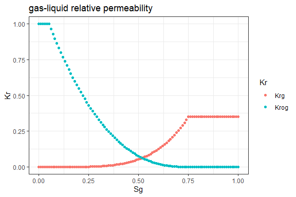

```r
p2 <- rel_perm_gl_df %>% tidyr::pivot_longer(cols = c(Krg, Krog), values_to = "value",
                                             names_to = "Kr") %>%
  ggplot(aes(x = Sg, y = value, col = Kr)) +
  geom_point() +
  labs(title = "gas-liquid relative permeability", x = "Sg", y = "Kr") +
  theme_bw()

p2
```

## `Three-phase Relative Permeability Examples`

#### Example 1:

```r
library(Rrelperm)
library(ggplot2)
library(ggtern)
library(magrittr)

rel_perm_owg_st_i_swsg <- kr3p_StoneI_SwSg(SWCON = 0.13, SWCRIT = 0.13, SOIRW = 0.20,
                                      SORW = 0.2, SOIRG = 0.1, SORG = 0.1, SGCON = 0,
                                      SGCRIT = 0, KRWIRO = 0.45, KROCW = 1, KRGCL = 0.35,
                                      NW = 4.25, NOW = 2.5, NG = 3, NOG = 2,
                                      NP = 501)

rel_perm_owg_st_i_swsg <- as.data.frame(rel_perm_owg_st_i_swsg)
colnames(rel_perm_owg_st_i_swsg) <- c("Sw", "Sg", "So", "Kro")

head(rel_perm_owg_st_i_swsg, 10)
```

```
#>    Sw    Sg    So       Kro
#> 1   0 0.000 1.000 1.0000000
#> 2   0 0.002 0.998 0.9952956
#> 3   0 0.004 0.996 0.9906019
#> 4   0 0.006 0.994 0.9859188
#> 5   0 0.008 0.992 0.9812464
#> 6   0 0.010 0.990 0.9765846
#> 7   0 0.012 0.988 0.9719336
#> 8   0 0.014 0.986 0.9672932
#> 9   0 0.016 0.984 0.9626635
#> 10  0 0.018 0.982 0.9580444
```

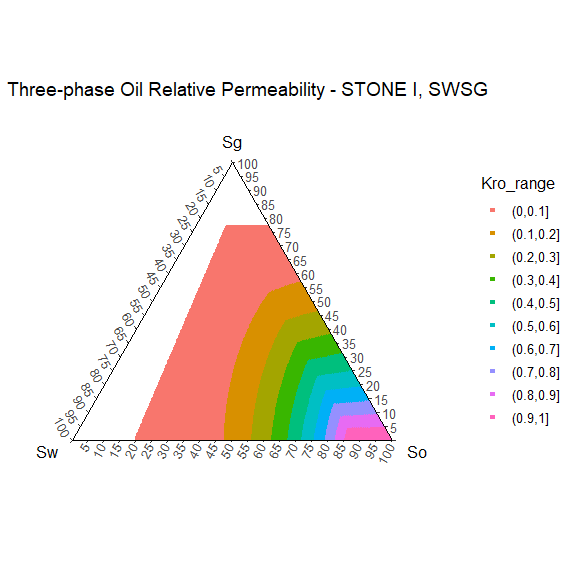

```r
rel_perm_owg_st_i_swsg$Kro_range <- cut(rel_perm_owg_st_i_swsg$Kro, breaks = seq(0,1, by = 0.1),
                                   right = TRUE, include.lowest = FALSE)

rel_perm_owg_st_i_swsg_oil <- rel_perm_owg_st_i_swsg[rel_perm_owg_st_i_swsg$Kro > 0, ]

rel_perm_owg_st_i_swsg_oil <- droplevels(rel_perm_owg_st_i_swsg_oil)

p3 <- ggtern(data = rel_perm_owg_st_i_swsg_oil, aes(x = Sw, y = Sg, z = So, value = Kro)) +
  geom_point(aes(value = Kro, fill = Kro_range, color = Kro_range), size = 1, shape = 22) +
  scale_T_continuous(limits = c(0.0,1.0), breaks = seq(0,1,by = 0.05)) +
  scale_L_continuous(limits = c(0.0,1.0), breaks = seq(0,1,by = 0.05)) +
  scale_R_continuous(limits = c(0.0,1.0), breaks = seq(0,1,by = 0.05)) +
  ggtitle("Three-phase Oil Relative Permeability - STONE I, SWSG") +
  theme_classic()
p3
```

#### Example 2:

```r
library(Rrelperm)
library(ggplot2)
library(ggtern)
library(magrittr)

rel_perm_owg_st_i_so <- kr3p_StoneI_So(SWCON = 0.13, SWCRIT = 0.13, SOIRW = 0.20,
                                      SORW = 0.2, SOIRG = 0.1, SORG = 0.1, SGCON = 0,
                                      SGCRIT = 0, KRWIRO = 0.45, KROCW = 1, KRGCL = 0.35,
                                      NW = 4.25, NOW = 2.5, NG = 3, NOG = 2,
                                      NP = 501)

rel_perm_owg_st_i_so <- as.data.frame(rel_perm_owg_st_i_so)
colnames(rel_perm_owg_st_i_so) <- c("Sw", "Sg", "So", "Kro")

head(rel_perm_owg_st_i_so, 10)
```

```
#>    Sw    Sg    So Kro
#> 1   0 0.000 1.000   1
#> 2   0 0.002 0.998   1
#> 3   0 0.004 0.996   1
#> 4   0 0.006 0.994   1
#> 5   0 0.008 0.992   1
#> 6   0 0.010 0.990   1
#> 7   0 0.012 0.988   1
#> 8   0 0.014 0.986   1
#> 9   0 0.016 0.984   1
#> 10  0 0.018 0.982   1
```

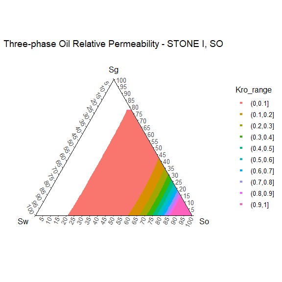

```r
rel_perm_owg_st_i_so$Kro_range <- cut(rel_perm_owg_st_i_so$Kro, breaks = seq(0,1, by = 0.1),
                                   right = TRUE, include.lowest = FALSE)

rel_perm_owg_st_i_so_oil <- rel_perm_owg_st_i_so[rel_perm_owg_st_i_so$Kro > 0, ]

rel_perm_owg_st_i_so_oil <- droplevels(rel_perm_owg_st_i_so_oil)

p4 <- ggtern(data = rel_perm_owg_st_i_so_oil, aes(x = Sw, y = Sg, z = So, value = Kro)) +
  geom_point(aes(value = Kro, fill = Kro_range, color = Kro_range), size = 1, shape = 22) +
  scale_T_continuous(limits = c(0.0,1.0), breaks = seq(0,1,by = 0.05)) +
  scale_L_continuous(limits = c(0.0,1.0), breaks = seq(0,1,by = 0.05)) +
  scale_R_continuous(limits = c(0.0,1.0), breaks = seq(0,1,by = 0.05)) +
  ggtitle("Three-phase Oil Relative Permeability - STONE I, SO") +
  theme_classic()
p4
```

#### Example 3:

```r
library(Rrelperm)
library(ggplot2)
library(ggtern)
library(magrittr)

rel_perm_owg_st_ii_swsg <- kr3p_StoneII_SwSg(SWCON = 0.13, SWCRIT = 0.13, SOIRW = 0.20,
                                      SORW = 0.2, SOIRG = 0.1, SORG = 0.1, SGCON = 0,
                                      SGCRIT = 0, KRWIRO = 0.45, KROCW = 1, KRGCL = 0.35,
                                      NW = 4.25, NOW = 2.5, NG = 3, NOG = 2,
                                      NP = 501)

rel_perm_owg_st_ii_swsg <- as.data.frame(rel_perm_owg_st_ii_swsg)
colnames(rel_perm_owg_st_ii_swsg) <- c("Sw", "Sg", "So", "Kro")

head(rel_perm_owg_st_ii_swsg, 10)
```

```
#>    Sw    Sg    So       Kro
#> 1   0 0.000 1.000 1.0000000
#> 2   0 0.002 0.998 0.9948119
#> 3   0 0.004 0.996 0.9896374
#> 4   0 0.006 0.994 0.9844763
#> 5   0 0.008 0.992 0.9793287
#> 6   0 0.010 0.990 0.9741946
#> 7   0 0.012 0.988 0.9690740
#> 8   0 0.014 0.986 0.9639669
#> 9   0 0.016 0.984 0.9588733
#> 10  0 0.018 0.982 0.9537932
```

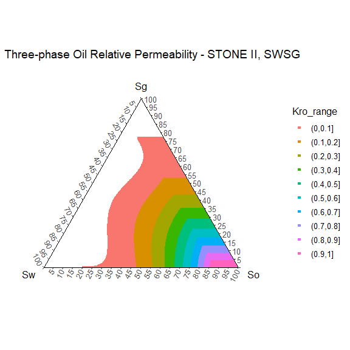

```r
rel_perm_owg_st_ii_swsg$Kro_range <- cut(rel_perm_owg_st_ii_swsg$Kro, breaks = seq(0,1, by = 0.1),
                                   right = TRUE, include.lowest = FALSE)

rel_perm_owg_st_ii_swsg_oil <- rel_perm_owg_st_ii_swsg[rel_perm_owg_st_ii_swsg$Kro > 0, ]

rel_perm_owg_st_ii_swsg_oil <- droplevels(rel_perm_owg_st_ii_swsg_oil)

p5 <- ggtern(data = rel_perm_owg_st_ii_swsg_oil, aes(x = Sw, y = Sg, z = So, value = Kro)) +
  geom_point(aes(value = Kro, fill = Kro_range, color = Kro_range), size = 1, shape = 22) +
  scale_T_continuous(limits = c(0.0,1.0), breaks = seq(0,1,by = 0.05)) +
  scale_L_continuous(limits = c(0.0,1.0), breaks = seq(0,1,by = 0.05)) +
  scale_R_continuous(limits = c(0.0,1.0), breaks = seq(0,1,by = 0.05)) +
  ggtitle("Three-phase Oil Relative Permeability - STONE II, SWSG") +
  theme_classic()
p5
```

#### Example 4:

```r
library(Rrelperm)
library(ggplot2)
library(ggtern)
library(magrittr)

rel_perm_owg_st_ii_so <- kr3p_StoneII_So(SWCON = 0.13, SWCRIT = 0.13, SOIRW = 0.20,
                                      SORW = 0.2, SOIRG = 0.1, SORG = 0.1, SGCON = 0,
                                      SGCRIT = 0, KRWIRO = 0.45, KROCW = 1, KRGCL = 0.35,
                                      NW = 4.25, NOW = 2.5, NG = 3, NOG = 2,
                                      NP = 501)

rel_perm_owg_st_ii_so <- as.data.frame(rel_perm_owg_st_ii_so)
colnames(rel_perm_owg_st_ii_so) <- c("Sw", "Sg", "So", "Kro")

head(rel_perm_owg_st_ii_so, 10)
```

```
#>    Sw    Sg    So Kro
#> 1   0 0.000 1.000   1
#> 2   0 0.002 0.998   1
#> 3   0 0.004 0.996   1
#> 4   0 0.006 0.994   1
#> 5   0 0.008 0.992   1
#> 6   0 0.010 0.990   1
#> 7   0 0.012 0.988   1
#> 8   0 0.014 0.986   1
#> 9   0 0.016 0.984   1
#> 10  0 0.018 0.982   1
```

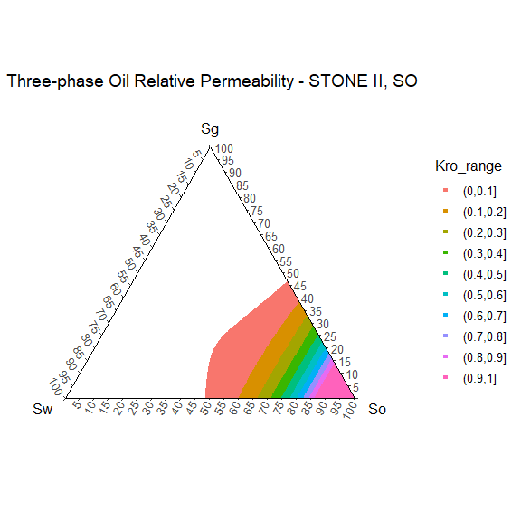

```r
rel_perm_owg_st_ii_so$Kro_range <- cut(rel_perm_owg_st_ii_so$Kro, breaks = seq(0,1, by = 0.1),
                                   right = TRUE, include.lowest = FALSE)

rel_perm_owg_st_ii_so_oil <- rel_perm_owg_st_ii_so[rel_perm_owg_st_ii_so$Kro > 0, ]

rel_perm_owg_st_ii_so_oil <- droplevels(rel_perm_owg_st_ii_so_oil)

p6 <- ggtern(data = rel_perm_owg_st_ii_so_oil, aes(x = Sw, y = Sg, z = So, value = Kro)) +
  geom_point(aes(value = Kro, fill = Kro_range, color = Kro_range), size = 1, shape = 22) +
  scale_T_continuous(limits = c(0.0,1.0), breaks = seq(0,1,by = 0.05)) +
  scale_L_continuous(limits = c(0.0,1.0), breaks = seq(0,1,by = 0.05)) +
  scale_R_continuous(limits = c(0.0,1.0), breaks = seq(0,1,by = 0.05)) +
  ggtitle("Three-phase Oil Relative Permeability - STONE II, SO") +
  theme_classic()
p6
```

#### Example 5:

```r
library(Rrelperm)
library(ggplot2)
library(ggtern)
library(magrittr)

rel_perm_owg_bk <- kr3p_Baker(SWCON = 0.13, SWCRIT = 0.13, SOIRW = 0.20,
                                      SORW = 0.2, SOIRG = 0.1, SORG = 0.1, SGCON = 0,
                                      SGCRIT = 0, KRWIRO = 0.45, KROCW = 1, KRGCL = 0.35,
                                      NW = 4.25, NOW = 2.5, NG = 3, NOG = 2,
                                      NP = 501)

rel_perm_owg_bk <- as.data.frame(rel_perm_owg_bk)
colnames(rel_perm_owg_bk) <- c("Sw", "Sg", "So", "Kro")

head(rel_perm_owg_bk, 10)
```

```
#>    Sw    Sg    So       Kro
#> 1   0 0.000 1.000 1.0000000
#> 2   0 0.002 0.998 0.9948119
#> 3   0 0.004 0.996 0.9896374
#> 4   0 0.006 0.994 0.9844763
#> 5   0 0.008 0.992 0.9793287
#> 6   0 0.010 0.990 0.9741946
#> 7   0 0.012 0.988 0.9690740
#> 8   0 0.014 0.986 0.9639669
#> 9   0 0.016 0.984 0.9588733
#> 10  0 0.018 0.982 0.9537932
```

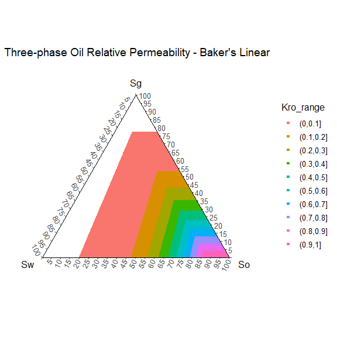

```r
rel_perm_owg_bk$Kro_range <- cut(rel_perm_owg_bk$Kro, breaks = seq(0,1, by = 0.1),
                                   right = TRUE, include.lowest = FALSE)

rel_perm_owg_bk_oil <- rel_perm_owg_bk[rel_perm_owg_bk$Kro > 0, ]

rel_perm_owg_bk_oil <- droplevels(rel_perm_owg_bk_oil)

p7 <- ggtern(data = rel_perm_owg_bk_oil, aes(x = Sw, y = Sg, z = So)) +
  geom_point(aes(value = Kro, fill = Kro_range, color = Kro_range), size = 1, shape = 22) +
  scale_T_continuous(limits = c(0.0,1.0), breaks = seq(0,1,by = 0.05)) +
  scale_L_continuous(limits = c(0.0,1.0), breaks = seq(0,1,by = 0.05)) +
  scale_R_continuous(limits = c(0.0,1.0), breaks = seq(0,1,by = 0.05)) +
  ggtitle("Three-phase Oil Relative Permeability - Baker's Linear") +
  theme_classic()
p7
```

## `References`

Baker, L. E. (1988). *Three-Phase Relative Permeability Correlations*. https://doi.org/10.2118/17369-MS

Brooks, R. H., & Corey, A. T. (1964). Hydraulic Properties of Porous Media. *Hydrology Papers*, (3), 27. Retrieved from https://mountainscholar.org/bitstream/handle/10217/61288/HydrologyPapers_n3.pdf

Fayers, F. J., & Matthews, J. D. (1984). Evaluation of Normalized Stone’s Methods for Estimating Three-Phase Relative Permeabilities. *Society of Petroleum Engineers Journal*, *24*(02), 224–232. https://doi.org/10.2118/11277-PA

Stone, H. L. (1970). Probability Model for Estimating Three-Phase Relative Permeability. *Journal of Petroleum Technology*, *22*(02), 214–218. https://doi.org/10.2118/2116-PA